# Informative prior archetypes

Informative prior archetypes allow users to conveniently set informative priors in `brms.mmrm` in a robust way, guarding against common pitfalls such as reference level issues, interpretation problems, and rank deficiency.

## Constructing an archetype

We begin with the FEV dataset from the `mmrm` package, an artificial (simulated) dataset of a clinical trial investigating the effect of an active treatment on FEV1 (forced expired volume in one second), compared to placebo. FEV1 is a measure of how quickly the lungs can be emptied and low levels may indicate chronic obstructive pulmonary disease (COPD).

- `USUBJID` (subject ID),
- `AVISIT` (visit number),
- `ARMCD` (treatment, TRT or PBO),
- `RACE` (3-category race),
- `SEX` (sex),
- `FEV1_BL` (FEV1 at baseline, %),
- `FEV1` (FEV1 at study visits),
- `WEIGHT` (weighting variable).

```r
library(brms.mmrm)
data(fev_data, package = "mmrm")
data <- fev_data |>
  brm_data(
    outcome = "FEV1",
    group = "ARMCD",
    time = "AVISIT",
    patient = "USUBJID",
    reference_time = "VIS1",
    reference_group = "PBO",
    covariates = c("WEIGHT", "SEX")
  ) |>
  brm_data_chronologize(order = "VISITN")
data
```

```
#> # A tibble: 800 × 10
#>    USUBJID AVISIT ARMCD RACE                      SEX    FEV1_BL  FEV1 WEIGHT VISITN VISITN2
#>    <fct>   <ord>  <fct> <fct>                     <fct>    <dbl> <dbl>  <dbl>  <int>   <dbl>
#>  1 PT2     VIS1   PBO   Asian                     Male      45.0  NA    0.465      1  0.330
#>  2 PT2     VIS2   PBO   Asian                     Male      45.0  31.5  0.233      2 -0.820
#>  3 PT2     VIS3   PBO   Asian                     Male      45.0  36.9  0.360      3  0.487
#>  4 PT2     VIS4   PBO   Asian                     Male      45.0  48.8  0.507      4  0.738
#>  5 PT3     VIS1   PBO   Black or African American Female    43.5  NA    0.682      1  0.576
#>  6 PT3     VIS2   PBO   Black or African American Female    43.5  36.0  0.892      2 -0.305
#>  7 PT3     VIS3   PBO   Black or African American Female    43.5  NA    0.128      3  1.51
#>  8 PT3     VIS4   PBO   Black or African American Female    43.5  37.2  0.222      4  0.390
#>  9 PT5     VIS1   PBO   Black or African American Male      43.6  32.3  0.411      1 -0.0162
#> 10 PT5     VIS2   PBO   Black or African American Male      43.6  NA    0.422      2  0.944
#> # ℹ 790 more rows
```

The functions listed at https://openpharma.github.io/brms.mmrm/reference/index.html#informative-prior-archetypes can create different kinds of informative prior archetypes from a dataset like the one above. For example, suppose we want to place informative priors on the successive differences between adjacent time points. This approach is appropriate and desirable in many situations because the structure naturally captures the prior correlations among adjacent visits of a clinical trial. To do this, we create an instance of the “successive cells” archetype.

```r
archetype <- brm_archetype_successive_cells(data, baseline = FALSE)
```

The instance of the archetype is an ordinary tibble, but it adds new columns with prefixes `"x_"` and `"nuisance_"`. These new columns constitute a custom model matrix to describe the desired parameterization.

```r
archetype
```

```
#> # A tibble: 800 × 20
#>    x_PBO_VIS1 x_PBO_VIS2 x_PBO_VIS3 x_PBO_VIS4 x_TRT_VIS1 x_TRT_VIS2 x_TRT_VIS3 x_TRT_VIS4 nuisance_WEIGHT
#>  *      <dbl>      <dbl>      <dbl>      <dbl>      <dbl>      <dbl>      <dbl>      <dbl>           <dbl>
#>  1          1          0          0          0          0          0          0          0         -0.0533
#>  2          1          1          0          0          0          0          0          0         -0.285
#>  3          1          1          1          0          0          0          0          0         -0.158
#>  4          1          1          1          1          0          0          0          0         -0.0111
#>  5          1          0          0          0          0          0          0          0          0.164
#>  6          1          1          0          0          0          0          0          0          0.373
#>  7          1          1          1          0          0          0          0          0         -0.391
#>  8          1          1          1          1          0          0          0          0         -0.297
#>  9          1          0          0          0          0          0          0          0         -0.108
#> 10          1          1          0          0          0          0          0          0         -0.0964
#> # ℹ 790 more rows
#> # ℹ 11 more variables: nuisance_SEX_Male <dbl>, USUBJID <fct>, AVISIT <ord>, ARMCD <fct>, RACE <fct>, SEX <fct>,
#> #   FEV1_BL <dbl>, FEV1 <dbl>, WEIGHT <dbl>, VISITN <int>, VISITN2 <dbl>
```

We have effects of interest to express successive differences:

```r
attr(archetype, "brm_archetype_interest")
```

```
#> [1] "x_PBO_VIS1" "x_PBO_VIS2" "x_PBO_VIS3" "x_PBO_VIS4" "x_TRT_VIS1" "x_TRT_VIS2" "x_TRT_VIS3" "x_TRT_VIS4"
```

We also have nuisance variables. Some nuisance variables are continuous covariates, while others are levels of one-hot-encoded concomitant factors or interactions of those concomitant factors with baseline and/or subgroup. All nuisance variables are centered so the reference level of the model is at the “center” of the data and not implicitly conditional on a subset of the data. Most nuisance variables are centered at their means across the whole dataset. Nuisance variables which interact baseline with time and/or the subgroup are centered only within the cell of the data they apply to, since those columns are zero everywhere else; centering them across the whole dataset would entangle them with the variables that marginal means average over.[^1] In addition, some nuisance variables are automatically dropped in order to ensure the model matrix is full-rank, and automatic centering in `brms` is disabled[^2]. This is critically important to preserve the interpretation of the columns of interest and make sure the informative priors behave as expected.

```r
attr(archetype, "brm_archetype_nuisance")
```

```
#> [1] "nuisance_WEIGHT"   "nuisance_SEX_Male"
```

The factors of interest linearly map to marginal means. To see the mapping, call `summary()` on the archetype. The printed output helps build intuition on how the archetype is parameterized and what those parameters are doing.[^3]

```r
summary(archetype)
```

```
#> # This is the "successive cells" informative prior archetype in brms.mmrm.
#> # The following equations show the relationships between the
#> # marginal means (left-hand side) and important fixed effect parameters
#> # (right-hand side). Nuisance parameters are omitted.
#> #
#> #   PBO:VIS1 = x_PBO_VIS1
#> #   PBO:VIS2 = x_PBO_VIS1 + x_PBO_VIS2
#> #   PBO:VIS3 = x_PBO_VIS1 + x_PBO_VIS2 + x_PBO_VIS3
#> #   PBO:VIS4 = x_PBO_VIS1 + x_PBO_VIS2 + x_PBO_VIS3 + x_PBO_VIS4
#> #   TRT:VIS1 = x_TRT_VIS1
#> #   TRT:VIS2 = x_TRT_VIS1 + x_TRT_VIS2
#> #   TRT:VIS3 = x_TRT_VIS1 + x_TRT_VIS2 + x_TRT_VIS3
#> #   TRT:VIS4 = x_TRT_VIS1 + x_TRT_VIS2 + x_TRT_VIS3 + x_TRT_VIS4
```

## Informative priors

Let’s assume you want to assign informative priors to the fixed effect parameters of interest declared in the archetype, such as `x_group_1_time_2` and `x_group_2_time_3`. Your priors may come from expert elicitation, historical data, or some other method, and you might consider [distributional families recommended by the Stan team](https://github.com/stan-dev/stan/wiki/prior-choice-recommendations). However you construct these priors, `brms.mmrm` helps you assign them to the model without having to guess at the automatically-generated names of model coefficients in R.

In the printed output from `summary(archetype)`, parameters of interest such as `x_group_1_time_2` and `x_group_2_time_3` are always labeled using treatment groups and time points in the data (and subgroup levels, if applicable). This labeling mechanism is the same regardless of which archetype you choose, and it the way `brms.mmrm` helps you assign priors.

`brm_prior_label()` is one way to create a labeling scheme. Each call to `brm_prior_label()` below assigns a univariate prior to a fixed effect parameter. Each univariate prior is a Stan code string. Possible choices are documented in the Stan function reference at https://mc-stan.org/docs/functions-reference/unbounded_continuous_distributions.html.

```r
label <- NULL |>
  brm_prior_label(code = "student_t(4, -7.57, 4.96)", group = "PBO", time = "VIS1") |>
  brm_prior_label(code = "student_t(4,  3.14, 7.86)", group = "PBO", time = "VIS2") |>
  brm_prior_label(code = "student_t(4,  8.78, 8.18)", group = "PBO", time = "VIS3") |>
  brm_prior_label(code = "student_t(4,  3.36, 8.10)", group = "PBO", time = "VIS4") |>
  brm_prior_label(code = "student_t(4, -2.96, 4.78)", group = "TRT", time = "VIS1") |>
  brm_prior_label(code = "student_t(4,  3.13, 7.64)", group = "TRT", time = "VIS2") |>
  brm_prior_label(code = "student_t(4,  7.65, 8.24)", group = "TRT", time = "VIS3") |>
  brm_prior_label(code = "student_t(4,  4.64, 8.21)", group = "TRT", time = "VIS4")
label
```

```
#> # A tibble: 8 × 3
#>   code                      group time
#>   <chr>                     <chr> <chr>
#> 1 student_t(4, -7.57, 4.96) PBO   VIS1
#> 2 student_t(4,  3.14, 7.86) PBO   VIS2
#> 3 student_t(4,  8.78, 8.18) PBO   VIS3
#> 4 student_t(4,  3.36, 8.10) PBO   VIS4
#> 5 student_t(4, -2.96, 4.78) TRT   VIS1
#> 6 student_t(4,  3.13, 7.64) TRT   VIS2
#> 7 student_t(4,  7.65, 8.24) TRT   VIS3
#> 8 student_t(4,  4.64, 8.21) TRT   VIS4
```

As an alternative to `brm_prior_label()`, you can start with a template and manually fill in the Stan code.

```r
template <- brm_prior_template(archetype)
template
```

```
#> # A tibble: 8 × 3
#>   code  group time
#>   <chr> <chr> <chr>
#> 1 <NA>  PBO   VIS1
#> 2 <NA>  PBO   VIS2
#> 3 <NA>  PBO   VIS3
#> 4 <NA>  PBO   VIS4
#> 5 <NA>  TRT   VIS1
#> 6 <NA>  TRT   VIS2
#> 7 <NA>  TRT   VIS3
#> 8 <NA>  TRT   VIS4
```

```r
label <- template |>
  mutate(
    code = c(
      "student_t(4, -7.57, 4.96)",
      "student_t(4,  3.14, 7.86)",
      "student_t(4,  8.78, 8.18)",
      "student_t(4,  3.36, 8.10)",
      "student_t(4, -2.96, 4.78)",
      "student_t(4,  3.13, 7.64)",
      "student_t(4,  7.65, 8.24)",
      "student_t(4,  4.64, 8.21)"
    )
  )
label
```

```
#> # A tibble: 8 × 3
#>   code                      group time
#>   <chr>                     <chr> <chr>
#> 1 student_t(4, -7.57, 4.96) PBO   VIS1
#> 2 student_t(4,  3.14, 7.86) PBO   VIS2
#> 3 student_t(4,  8.78, 8.18) PBO   VIS3
#> 4 student_t(4,  3.36, 8.10) PBO   VIS4
#> 5 student_t(4, -2.96, 4.78) TRT   VIS1
#> 6 student_t(4,  3.13, 7.64) TRT   VIS2
#> 7 student_t(4,  7.65, 8.24) TRT   VIS3
#> 8 student_t(4,  4.64, 8.21) TRT   VIS4
```

After you have a labeling scheme, `brm_prior_archetype()` can create a `brms` prior for the important fixed effects.[^4]

```r
prior <- brm_prior_archetype(label = label, archetype = archetype)
prior
```

```
#>                      prior class       coef group resp dpar nlpar   lb   ub tag source
#>  student_t(4, -7.57, 4.96)     b x_PBO_VIS1                       <NA> <NA>       user
#>  student_t(4,  3.14, 7.86)     b x_PBO_VIS2                       <NA> <NA>       user
#>  student_t(4,  8.78, 8.18)     b x_PBO_VIS3                       <NA> <NA>       user
#>  student_t(4,  3.36, 8.10)     b x_PBO_VIS4                       <NA> <NA>       user
#>  student_t(4, -2.96, 4.78)     b x_TRT_VIS1                       <NA> <NA>       user
#>  student_t(4,  3.13, 7.64)     b x_TRT_VIS2                       <NA> <NA>       user
#>  student_t(4,  7.65, 8.24)     b x_TRT_VIS3                       <NA> <NA>       user
#>  student_t(4,  4.64, 8.21)     b x_TRT_VIS4                       <NA> <NA>       user
```

```r
brm_formula(archetype)
```

```
#> FEV1 ~ 0 + x_PBO_VIS1 + x_PBO_VIS2 + x_PBO_VIS3 + x_PBO_VIS4 + x_TRT_VIS1 + x_TRT_VIS2 + x_TRT_VIS3 + x_TRT_VIS4 + nuisance_WEIGHT + nuisance_SEX_Male + unstr(time = AVISIT, gr = USUBJID)
#> sigma ~ 0 + AVISIT
```

The model still has many parameters where we did not set priors, and `brms` sets automatic defaults. You can see these defaults with `brms::get_prior()`.

https://paulbuerkner.com/brms/reference/set_prior.html documents many of the default priors set by `brms`. In particular, `"(flat)"` denotes an improper uniform prior over all the real numbers.

## Modeling and analysis

The downstream methods in `brms.mmrm` automatically understand how to work with informative prior archetypes. Notably, the formula uses custom interest and nuisance variables instead of the original variables in the data.

```r
formula <- brm_formula(archetype)
formula
```

```
#> FEV1 ~ 0 + x_PBO_VIS1 + x_PBO_VIS2 + x_PBO_VIS3 + x_PBO_VIS4 + x_TRT_VIS1 + x_TRT_VIS2 + x_TRT_VIS3 + x_TRT_VIS4 + nuisance_WEIGHT + nuisance_SEX_Male + unstr(time = AVISIT, gr = USUBJID)
#> sigma ~ 0 + AVISIT
```

The model can accept the archetype, formula, and prior. Usage is the same as in non-archetype workflows.

```r
model <- brm_model(
  data = archetype,
  formula = formula,
  prior = prior,
  refresh = 0
)
```

```
#> Running MCMC with 4 sequential chains...
#>
#> Chain 1 finished in 5.1 seconds.
#> Chain 2 finished in 4.9 seconds.
#> Chain 3 finished in 4.7 seconds.
#> Chain 4 finished in 5.1 seconds.
#>
#> All 4 chains finished successfully.
#> Mean chain execution time: 5.0 seconds.
#> Total execution time: 20.3 seconds.
```

```r
brms::prior_summary(model)
```

```
#>                      prior    class              coef group resp  dpar nlpar lb ub tag       source
#>                     (flat)        b                                                         default
#>                     (flat)        b nuisance_SEX_Male                                  (vectorized)
#>                     (flat)        b   nuisance_WEIGHT                                  (vectorized)
#>  student_t(4, -7.57, 4.96)        b        x_PBO_VIS1                                          user
#>  student_t(4,  3.14, 7.86)        b        x_PBO_VIS2                                          user
#>  student_t(4,  8.78, 8.18)        b        x_PBO_VIS3                                          user
#>  student_t(4,  3.36, 8.10)        b        x_PBO_VIS4                                          user
#>  student_t(4, -2.96, 4.78)        b        x_TRT_VIS1                                          user
#>  student_t(4,  3.13, 7.64)        b        x_TRT_VIS2                                          user
#>  student_t(4,  7.65, 8.24)        b        x_TRT_VIS3                                          user
#>  student_t(4,  4.64, 8.21)        b        x_TRT_VIS4                                          user
#>                     (flat)        b                              sigma                      default
#>                     (flat)        b        AVISITVIS1            sigma                 (vectorized)
#>                     (flat)        b        AVISITVIS2            sigma                 (vectorized)
#>                     (flat)        b        AVISITVIS3            sigma                 (vectorized)
#>                     (flat)        b        AVISITVIS4            sigma                 (vectorized)
#>       lkj_corr_cholesky(1) Lcortime                                                         default
```

Marginal mean estimation, post-processing, and visualization automatically understand the archetype without any user intervention.

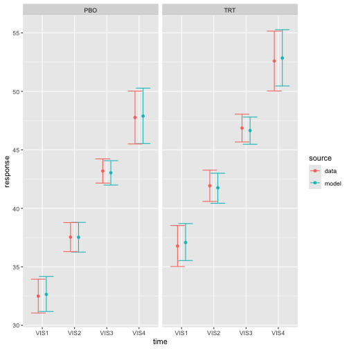

```r
draws <- brm_marginal_draws(
  data = archetype,
  formula = formula,
  model = model
)
summaries_model <- brm_marginal_summaries(draws)
summaries_data <- brm_marginal_data(archetype)
brm_plot_compare(model = summaries_model, data = summaries_data)
```

## All archetypes

`brms.mmrm` supports a variety of informative prior archetypes with different kinds of fixed effects. For example, `brms.mmrm` supports simple cell mean and treatment effect parameterizations.

```r
summary(brm_archetype_cells(data, intercept = FALSE))
```

```
#> # This is the "cells" informative prior archetype in brms.mmrm.
#> # The following equations show the relationships between the
#> # marginal means (left-hand side) and important fixed effect parameters
#> # (right-hand side). Nuisance parameters are omitted.
#> #
#> #   PBO:VIS1 = x_PBO_VIS1
#> #   PBO:VIS2 = x_PBO_VIS2
#> #   PBO:VIS3 = x_PBO_VIS3
#> #   PBO:VIS4 = x_PBO_VIS4
#> #   TRT:VIS1 = x_TRT_VIS1
#> #   TRT:VIS2 = x_TRT_VIS2
#> #   TRT:VIS3 = x_TRT_VIS3
#> #   TRT:VIS4 = x_TRT_VIS4
```

```r
summary(brm_archetype_effects(data, intercept = FALSE))
```

```
#> # This is the "effects" informative prior archetype in brms.mmrm.
#> # The following equations show the relationships between the
#> # marginal means (left-hand side) and important fixed effect parameters
#> # (right-hand side). Nuisance parameters are omitted.
#> #
#> #   PBO:VIS1 = x_PBO_VIS1
#> #   PBO:VIS2 = x_PBO_VIS2
#> #   PBO:VIS3 = x_PBO_VIS3
#> #   PBO:VIS4 = x_PBO_VIS4
#> #   TRT:VIS1 = x_PBO_VIS1 + x_TRT_VIS1
#> #   TRT:VIS2 = x_PBO_VIS2 + x_TRT_VIS2
#> #   TRT:VIS3 = x_PBO_VIS3 + x_TRT_VIS3
#> #   TRT:VIS4 = x_PBO_VIS4 + x_TRT_VIS4
```

```r
summary(brm_archetype_average_cells(data, intercept = FALSE))
```

```
#> # This is the "average cells" informative prior archetype in brms.mmrm.
#> # The following equations show the relationships between the
#> # marginal means (left-hand side) and important fixed effect parameters
#> # (right-hand side). Nuisance parameters are omitted.
#> #
#> #   PBO:VIS1 = 4*x_PBO_VIS1 - x_PBO_VIS2 - x_PBO_VIS3 - x_PBO_VIS4
#> #   PBO:VIS2 = x_PBO_VIS2
#> #   PBO:VIS3 = x_PBO_VIS3
#> #   PBO:VIS4 = x_PBO_VIS4
#> #   TRT:VIS1 = 4*x_TRT_VIS1 - x_TRT_VIS2 - x_TRT_VIS3 - x_TRT_VIS4
#> #   TRT:VIS2 = x_TRT_VIS2
#> #   TRT:VIS3 = x_TRT_VIS3
#> #   TRT:VIS4 = x_TRT_VIS4
```

```r
summary(brm_archetype_average_effects(data, intercept = FALSE))
```

```
#> # This is the "average effects" informative prior archetype in brms.mmrm.
#> # The following equations show the relationships between the
#> # marginal means (left-hand side) and important fixed effect parameters
#> # (right-hand side). Nuisance parameters are omitted.
#> #
#> #   PBO:VIS1 = 4*x_PBO_VIS1 - x_PBO_VIS2 - x_PBO_VIS3 - x_PBO_VIS4
#> #   PBO:VIS2 = x_PBO_VIS2
#> #   PBO:VIS3 = x_PBO_VIS3
#> #   PBO:VIS4 = x_PBO_VIS4
#> #   TRT:VIS1 = 4*x_PBO_VIS1 - x_PBO_VIS2 - x_PBO_VIS3 - x_PBO_VIS4 + 4*x_TRT_VIS1 - x_TRT_VIS2 - x_TRT_VIS3 - x_TRT_VIS4
#> #   TRT:VIS2 = x_PBO_VIS2 + x_TRT_VIS2
#> #   TRT:VIS3 = x_PBO_VIS3 + x_TRT_VIS3
#> #   TRT:VIS4 = x_PBO_VIS4 + x_TRT_VIS4
```

The example in this vignette uses the “successive cells” archetype, where fixed effects represent successive differences between adjacent time points.

```r
summary(brm_archetype_successive_cells(data, intercept = FALSE))
```

```
#> # This is the "successive cells" informative prior archetype in brms.mmrm.
#> # The following equations show the relationships between the
#> # marginal means (left-hand side) and important fixed effect parameters
#> # (right-hand side). Nuisance parameters are omitted.
#> #
#> #   PBO:VIS1 = x_PBO_VIS1
#> #   PBO:VIS2 = x_PBO_VIS1 + x_PBO_VIS2
#> #   PBO:VIS3 = x_PBO_VIS1 + x_PBO_VIS2 + x_PBO_VIS3
#> #   PBO:VIS4 = x_PBO_VIS1 + x_PBO_VIS2 + x_PBO_VIS3 + x_PBO_VIS4
#> #   TRT:VIS1 = x_TRT_VIS1
#> #   TRT:VIS2 = x_TRT_VIS1 + x_TRT_VIS2
#> #   TRT:VIS3 = x_TRT_VIS1 + x_TRT_VIS2 + x_TRT_VIS3
#> #   TRT:VIS4 = x_TRT_VIS1 + x_TRT_VIS2 + x_TRT_VIS3 + x_TRT_VIS4
```

There is also a treatment effect version of the successive differences archetype:

```r
summary(brm_archetype_successive_effects(data, intercept = FALSE))
```

```
#> # This is the "successive effects" informative prior archetype in brms.mmrm.
#> # The following equations show the relationships between the
#> # marginal means (left-hand side) and important fixed effect parameters
#> # (right-hand side). Nuisance parameters are omitted.
#> #
#> #   PBO:VIS1 = x_PBO_VIS1
#> #   PBO:VIS2 = x_PBO_VIS1 + x_PBO_VIS2
#> #   PBO:VIS3 = x_PBO_VIS1 + x_PBO_VIS2 + x_PBO_VIS3
#> #   PBO:VIS4 = x_PBO_VIS1 + x_PBO_VIS2 + x_PBO_VIS3 + x_PBO_VIS4
#> #   TRT:VIS1 = x_PBO_VIS1 + x_TRT_VIS1
#> #   TRT:VIS2 = x_PBO_VIS1 + x_PBO_VIS2 + x_TRT_VIS1 + x_TRT_VIS2
#> #   TRT:VIS3 = x_PBO_VIS1 + x_PBO_VIS2 + x_PBO_VIS3 + x_TRT_VIS1 + x_TRT_VIS2 + x_TRT_VIS3
#> #   TRT:VIS4 = x_PBO_VIS1 + x_PBO_VIS2 + x_PBO_VIS3 + x_PBO_VIS4 + x_TRT_VIS1 + x_TRT_VIS2 + x_TRT_VIS3 + x_TRT_VIS4
```

## Variations on archetypes

Archetypes can be customized. As an example, consider the simple cell means archetype.

```r
summary(brm_archetype_cells(data))
```

```
#> # This is the "cells" informative prior archetype in brms.mmrm.
#> # The following equations show the relationships between the
#> # marginal means (left-hand side) and important fixed effect parameters
#> # (right-hand side). Nuisance parameters are omitted.
#> #
#> #   PBO:VIS1 = x_PBO_VIS1
#> #   PBO:VIS2 = x_PBO_VIS2
#> #   PBO:VIS3 = x_PBO_VIS3
#> #   PBO:VIS4 = x_PBO_VIS4
#> #   TRT:VIS1 = x_TRT_VIS1
#> #   TRT:VIS2 = x_TRT_VIS2
#> #   TRT:VIS3 = x_TRT_VIS3
#> #   TRT:VIS4 = x_TRT_VIS4
```

To include an intercept term which all the marginal means share, set `intercept = TRUE`.

```r
summary(brm_archetype_cells(data, intercept = TRUE))
```

```
#> # This is the "cells" informative prior archetype in brms.mmrm.
#> # The following equations show the relationships between the
#> # marginal means (left-hand side) and important fixed effect parameters
#> # (right-hand side). Nuisance parameters are omitted.
#> #
#> #   PBO:VIS1 = x_PBO_VIS1
#> #   PBO:VIS2 = x_PBO_VIS1 + x_PBO_VIS2
#> #   PBO:VIS3 = x_PBO_VIS1 + x_PBO_VIS3
#> #   PBO:VIS4 = x_PBO_VIS1 + x_PBO_VIS4
#> #   TRT:VIS1 = x_PBO_VIS1 + x_TRT_VIS1
#> #   TRT:VIS2 = x_PBO_VIS1 + x_TRT_VIS2
#> #   TRT:VIS3 = x_PBO_VIS1 + x_TRT_VIS3
#> #   TRT:VIS4 = x_PBO_VIS1 + x_TRT_VIS4
```

To set up constrained longitudinal data analysis (cLDA), set `clda = TRUE`. This constraint pools all treatment groups at baseline, and it can help model clinical trials where a baseline measurement is observed before randomization. Some archetypes cannot support cLDA (e.g. `brm_archetype_average_cells()` and `brm_archetype_average_effects()`).

```r
summary(brm_archetype_cells(data, clda = TRUE))
```

```
#> # This is the "cells" informative prior archetype in brms.mmrm.
#> # The following equations show the relationships between the
#> # marginal means (left-hand side) and important fixed effect parameters
#> # (right-hand side). Nuisance parameters are omitted.
#> #
#> #   PBO:VIS1 = x_PBO_VIS1
#> #   PBO:VIS2 = x_PBO_VIS2
#> #   PBO:VIS3 = x_PBO_VIS3
#> #   PBO:VIS4 = x_PBO_VIS4
#> #   TRT:VIS1 = x_PBO_VIS1
#> #   TRT:VIS2 = x_TRT_VIS2
#> #   TRT:VIS3 = x_TRT_VIS3
#> #   TRT:VIS4 = x_TRT_VIS4
```

[^1]: `brm_recenter_nuisance()` can retroactively recenter a nuisance column to a fixed value other than its mean.
[^2]: `brm_formula()` assigns `center = FALSE` in `brmsformula()` for all inforamtive prior archetypes.
[^3]: `summary()` also invisibly returns a simple character vector with the equations below.
[^4]: `brms` priors are documented in https://paulbuerkner.com/brms/reference/set_prior.html.